# Reproducible Research > Week 2 > Course Project 1

## Overview

This assignment makes use of data from a personal activity monitoring device. This device collects data at 5 minute intervals through out the day. The data consists of two months of data from an anonymous individual collected during the months of October and November, 2012 and include the number of steps taken in 5 minute intervals each day.

The data for this assignment can be downloaded from the course web site:

Dataset: [Activity monitoring data](https://d396qusza40orc.cloudfront.net/repdata%2Fdata%2Factivity.zip)[52KB]

The variables included in this dataset are:

**steps**: Number of steps taking in a 5-minute interval (missing values are coded as `NA`)

**date**: The date on which the measurement was taken in YYYY-MM-DD format

**interval**: Identifier for the 5-minute interval in which measurement was taken The dataset is stored in a comma-separated-value (CSV) file and there are a total of 17,568 observations in this dataset.

## Procedure

1. Code for reading in the dataset and/or processing the data
2. Histogram of the total number of steps taken each day
3. Mean and median number of steps taken each day
4. Time series plot of the average number of steps taken
5. The 5-minute interval that, on average, contains the maximum number of steps
6. Code to describe and show a strategy for imputing missing data
7. Histogram of the total number of steps taken each day after missing values are imputed
8. Panel plot comparing the average number of steps taken per 5-minute interval across weekdays and weekends
9. All of the R code needed to reproduce the results (numbers, plots, etc.) in the report

## Code

### 1. Code for reading in the dataset and/or processing the data

#### read data, create baseline data:

```r
library(scales)
library(dplyr)
library(readr)
```

```r
library(ggplot2)
library(tidyr)
library(lubridate)
url <- "https://d396qusza40orc.cloudfront.net/repdata%2Fdata%2Factivity.zip"
if(!file.exists("activity.zip")) download.file(url,"activity.zip",method="curl")
data <- {unzip("activity.zip")}
```

#### transform **interval** into hour + minutes(*2digits* + *2ditits*)

#### create datetime as POSIXct and then create act_df

```r
read_csv(data,col_types="ncn") %>%
  mutate(interval=formatC(interval,width=4,flag="0")) %>%
  mutate(datetime=as.POSIXct(paste(date,interval),format="%Y-%m-%d %H%M")) %>%
  mutate(date=as.Date(date,"%Y-%m-%d")) -> activity_df
```

```r
str(activity_df)
```

```
## Classes 'spec_tbl_df', 'tbl_df', 'tbl' and 'data.frame': 17568 obs. of  4 variables:
##  $ steps   : num  NA NA NA NA NA NA NA NA NA NA ...
##  $ date    : Date, format: "2012-10-01" "2012-10-01" ...
##  $ interval: chr  "0000" "0005" "0010" "0015" ...
##  $ datetime: POSIXct, format: "2012-10-01 00:00:00" "2012-10-01 00:05:00" ...
```

### 2. Histogram of the total number of steps taken each day

#### create dataframe:

```r
activity_df %>%
  group_by(date) %>%
  summarise(total= sum(steps,na.rm=TRUE)) %>%
  ungroup(date)-> hist_df
```

```r
hist_df
```

```
## # A tibble: 61 x 2
##    date       total
##    <date>     <dbl>
##  1 2012-10-01     0
##  2 2012-10-02   126
##  3 2012-10-03 11352
##  4 2012-10-04 12116
##  5 2012-10-05 13294
##  6 2012-10-06 15420
##  7 2012-10-07 11015
##  8 2012-10-08     0
##  9 2012-10-09 12811
## 10 2012-10-10  9900
## # ... with 51 more rows
```

#### plot:

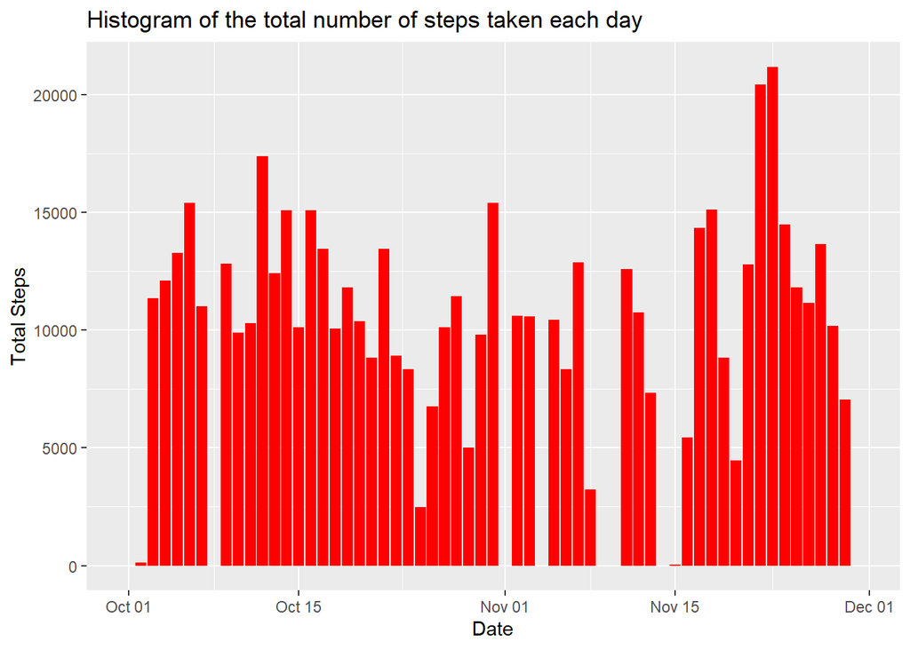

```r
ggplot(hist_df, aes(x=date,y=total)) +
  geom_col(fill="red") +
  ggtitle("Histogram of the total number of steps taken each day") +
             xlab("Date") + ylab("Total Steps")
```

### 3. Mean and median number of steps taken each day

#### create dataframe:

*Median did not appear as it was, so 0 was excluded*

```r
activity_df %>% group_by(date) %>%
  filter(steps!=0) %>%
  summarise(median=median(steps,na.rm=TRUE)) -> median_df
activity_df %>% group_by(date) %>%
  summarise(mean=mean(steps,na.rm=TRUE)) -> mean_df
mean_median_df <- inner_join(mean_df,median_df,by="date") %>%
  gather("summary","count",2:3)
```

```r
mean_median_df
```

```
## # A tibble: 106 x 3
##    date       summary  count
##    <date>     <chr>    <dbl>
##  1 2012-10-02 mean     0.438
##  2 2012-10-03 mean    39.4
##  3 2012-10-04 mean    42.1
##  4 2012-10-05 mean    46.2
##  5 2012-10-06 mean    53.5
##  6 2012-10-07 mean    38.2
##  7 2012-10-09 mean    44.5
##  8 2012-10-10 mean    34.4
##  9 2012-10-11 mean    35.8
## 10 2012-10-12 mean    60.4
## # ... with 96 more rows
```

#### plot:

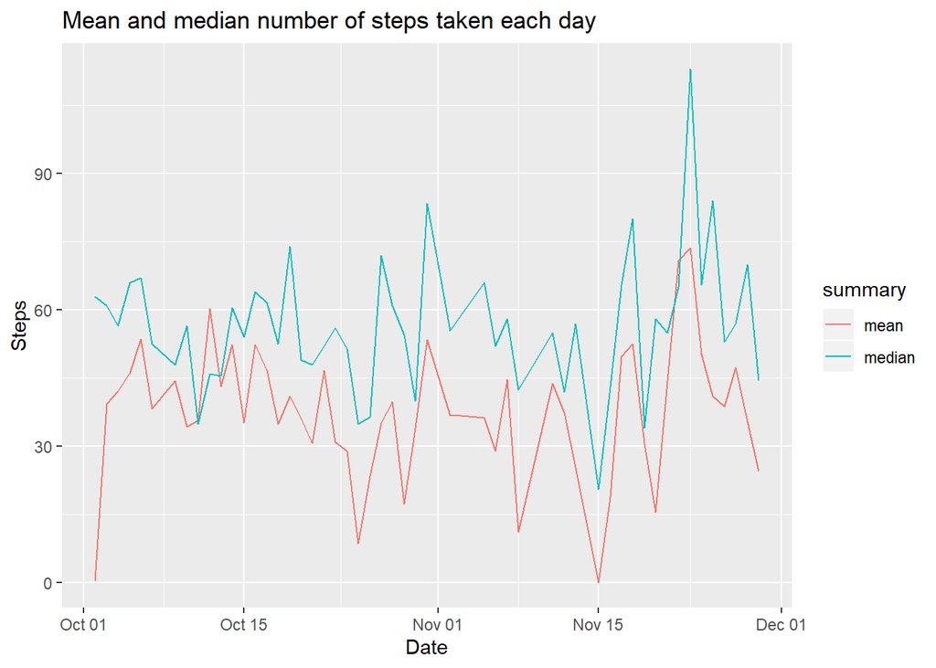

```r
ggplot(mean_median_df) +
  geom_line(aes(x=date,y=count,color=summary)) +
  ggtitle("Mean and median number of steps taken each day") +
  xlab("Date") + ylab("Steps")
```

### 4. Time series plot of the average number of steps taken

#### create dataframe:

*My time locale is bad, so change to UTC*

```r
activity_df %>% group_by(interval) %>%
  summarise(average=mean(steps,na.rm=TRUE)) %>%
  mutate(interval=as.POSIXct(interval,tz="UTC",format="%H%M"))  -> avg_df
```

```r
avg_df
```

```
## # A tibble: 288 x 2
##    interval            average
##    <dttm>                <dbl>
##  1 2019-08-20 00:00:00  1.72
##  2 2019-08-20 00:05:00  0.340
##  3 2019-08-20 00:10:00  0.132
##  4 2019-08-20 00:15:00  0.151
##  5 2019-08-20 00:20:00  0.0755
##  6 2019-08-20 00:25:00  2.09
##  7 2019-08-20 00:30:00  0.528
##  8 2019-08-20 00:35:00  0.868
##  9 2019-08-20 00:40:00  0
## 10 2019-08-20 00:45:00  1.47
## # ... with 278 more rows
```

#### plot:

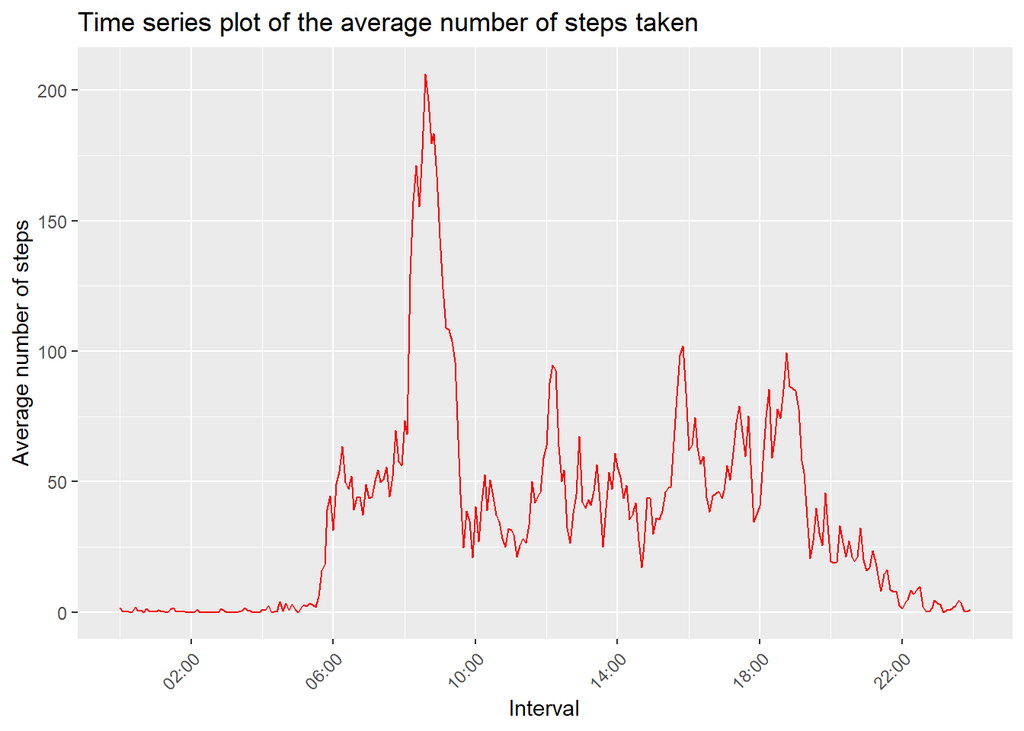

```r
ggplot(avg_df) +
  geom_line(aes(x=interval,y=average),color="red") +
  scale_x_datetime(breaks = date_breaks("4 hour"), labels = date_format("%H:%M")) +
  ggtitle("Time series plot of the average number of steps taken") +
  xlab("Interval") + ylab("Average number of steps") +
  theme(axis.text.x = element_text(angle = 45, hjust = 1))
```

#### create dataframe:

```r
activity_df %>% group_by(interval) %>%
  summarise(average=mean(steps,na.rm=TRUE),max=max(steps,na.rm=TRUE)) %>%
  mutate(interval=as.POSIXct(interval,tz="UTC",format="%H%M")) %>%
  ungroup(interval) %>%
  select(interval,average,max) %>%
  gather("summary","count",2:3) -> avg_max_df
```

```r
avg_max_df
```

```
## # A tibble: 576 x 3
##    interval            summary  count
##    <dttm>              <chr>    <dbl>
##  1 2019-08-20 00:00:00 average 1.72
##  2 2019-08-20 00:05:00 average 0.340
##  3 2019-08-20 00:10:00 average 0.132
##  4 2019-08-20 00:15:00 average 0.151
##  5 2019-08-20 00:20:00 average 0.0755
##  6 2019-08-20 00:25:00 average 2.09
##  7 2019-08-20 00:30:00 average 0.528
##  8 2019-08-20 00:35:00 average 0.868
##  9 2019-08-20 00:40:00 average 0
## 10 2019-08-20 00:45:00 average 1.47
## # ... with 566 more rows
```

#### plot:

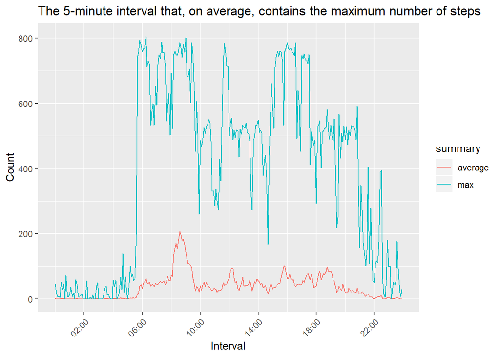

```r
ggplot() +
  geom_line(data=avg_max_df,aes(x=interval,y=count,color=summary))  +
  scale_x_datetime(breaks = date_breaks("4 hour"), labels = date_format("%H:%M")) +
  ggtitle("The 5-minute interval that, on average, contains the maximum number of steps") +
  xlab("Interval") + ylab("Count") +
  theme(axis.text.x = element_text(angle = 45, hjust = 1))
```

### 6. Code to describe and show a strategy for imputing missing data

#### show missing data

```r
activity_df %>% filter(is.na(steps)) %>%
  group_by(date) %>%
  summarise(count=n()) %>%
  ungroup(date)
```

```
## # A tibble: 8 x 2
##   date       count
##   <date>     <int>
## 1 2012-10-01   288
## 2 2012-10-08   288
## 3 2012-11-01   288
## 4 2012-11-04   288
## 5 2012-11-09   288
## 6 2012-11-10   288
## 7 2012-11-14   288
## 8 2012-11-30   288
```

#### show a strategy for imputing missing data

*Assign 0 to NA*

```r
activity_df %>% mutate(steps=if_else(is.na(steps),0,steps))
```

```
## # A tibble: 17,568 x 4
##    steps date       interval datetime
##    <dbl> <date>     <chr>    <dttm>
##  1     0 2012-10-01 0000     2012-10-01 00:00:00
##  2     0 2012-10-01 0005     2012-10-01 00:05:00
##  3     0 2012-10-01 0010     2012-10-01 00:10:00
##  4     0 2012-10-01 0015     2012-10-01 00:15:00
##  5     0 2012-10-01 0020     2012-10-01 00:20:00
##  6     0 2012-10-01 0025     2012-10-01 00:25:00
##  7     0 2012-10-01 0030     2012-10-01 00:30:00
##  8     0 2012-10-01 0035     2012-10-01 00:35:00
##  9     0 2012-10-01 0040     2012-10-01 00:40:00
## 10     0 2012-10-01 0045     2012-10-01 00:45:00
## # ... with 17,558 more rows
```